# Introduction to R Problem Set

# 3.6 Exercises

Complete all exercises for this section.

## 1

What geom would you use to draw a line chart? A boxplot? A histogram? An area chart?

```r
# line: geom_line or geom_path
# boxplot: geom_boxplot
# histogram: geom_histogram
# area chart: geom_area
```

## 2

Run this code in your head and predict what the output will look like. Then, run the code in *R* and check your predictions.

`ggplot(data = mpg, mapping = aes(x = displ, y = hwy, color = drv)) + geom_point() + geom_smooth(se = FALSE)`

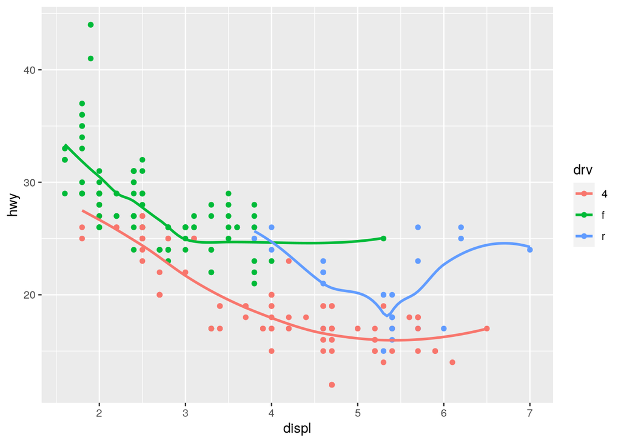

```r
ggplot(data = mpg, mapping = aes(x = displ, y = hwy, color = drv)) +
  geom_point() +
  geom_smooth(se = FALSE)
```

## 3

What does `show.legend = FALSE` do? What happens if you remove it? Why do you think I used it earlier in the chapter?

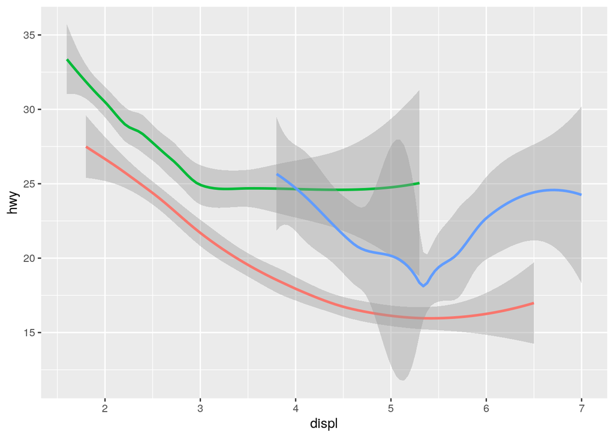

```r
ggplot(data = mpg) +
  geom_smooth(
    mapping = aes(x = displ, y = hwy, color = drv),
    show.legend = FALSE
  )
```

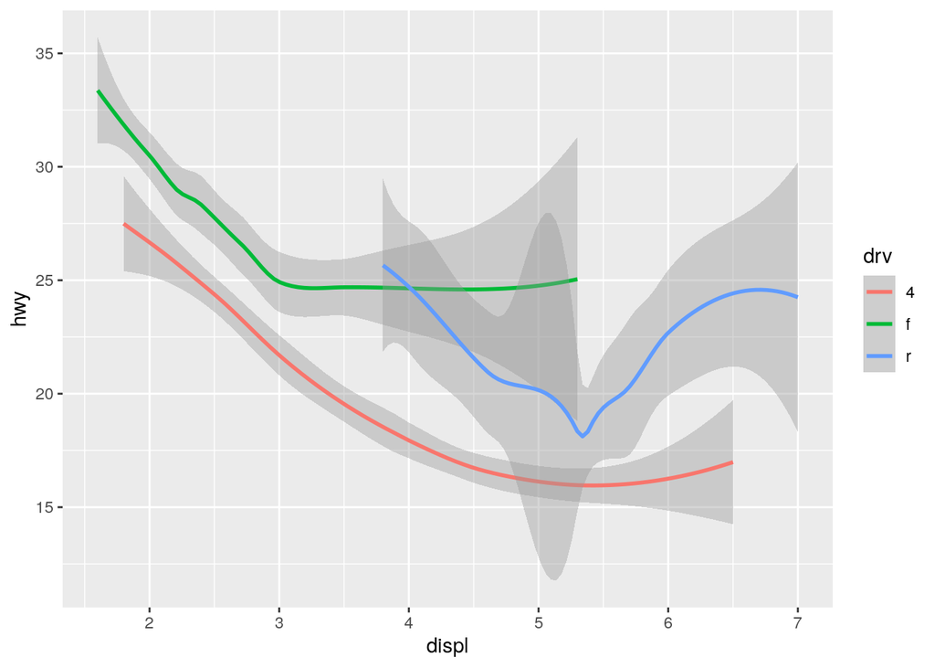

```r
# show.legend = FALSE removes the plot legend.

ggplot(data = mpg) +
  geom_smooth(
    mapping = aes(x = displ, y = hwy, color = drv)
  )
```

## 4

What does the `se` argument to `geom_smooth()` do? Note: we will cover smoothers in detail in the non-parametric regression chapter of the DoE tutorial.

```r
# Displays a confidence interval for the smooth line (controlled with `level`).
```

## 5

Will these two graphs look different? Why/why not?

`ggplot(data = mpg, mapping = aes(x = displ, y = hwy)) + geom_point() + geom_smooth()`

`ggplot() + geom_point(data = mpg, mapping = aes(x = displ, y = hwy)) + geom_smooth(data = mpg, mapping = aes(x = displ, y = hwy))`

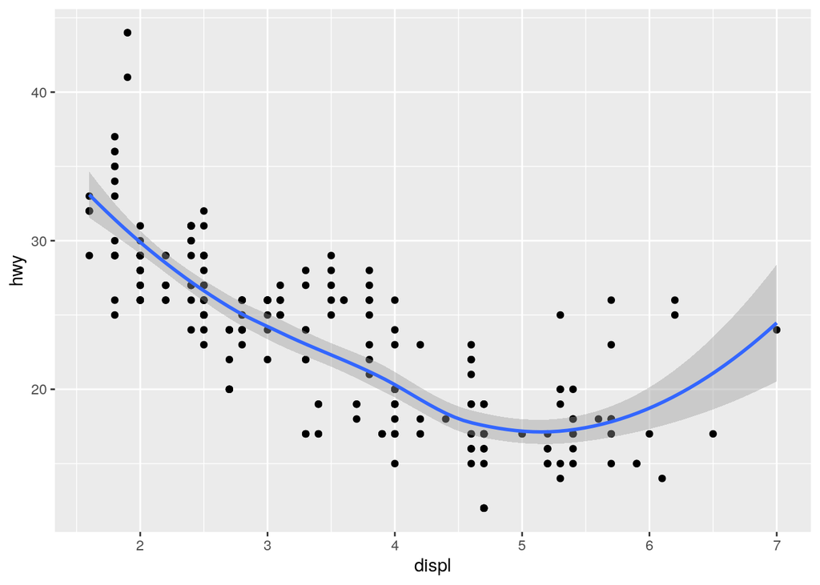

```r
# They will look the same because both geom mappings in the second plot
# are the same as the global mapping in the first plot.

ggplot(data = mpg, mapping = aes(x = displ, y = hwy)) +
  geom_point() +
  geom_smooth()
```

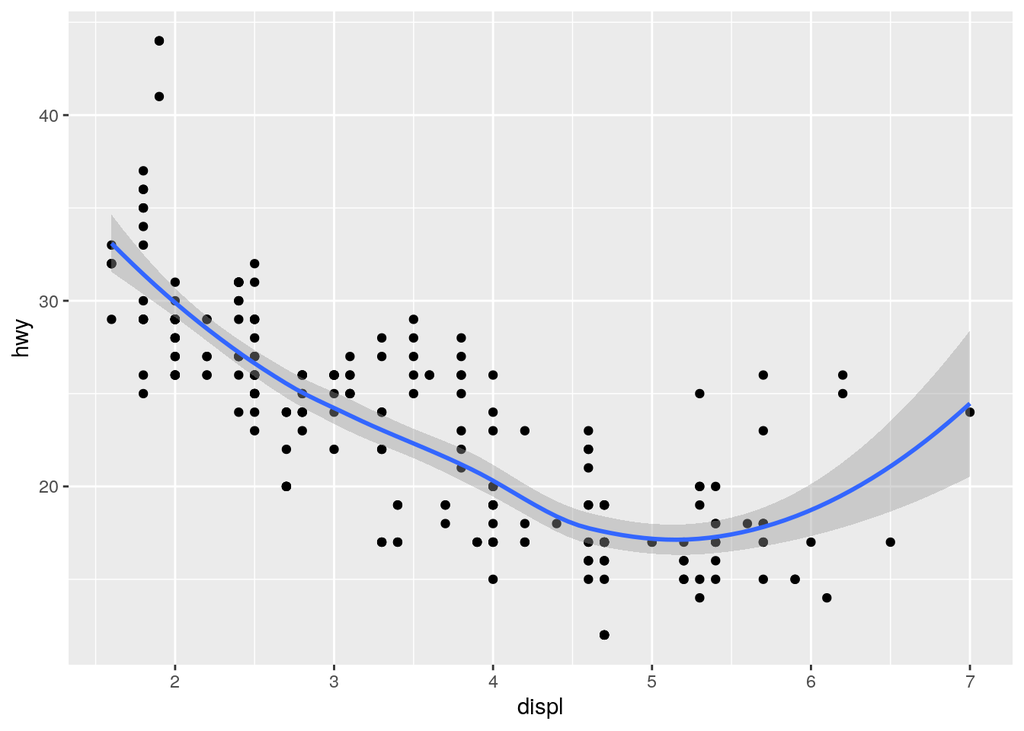

```r
ggplot() +
  geom_point(data = mpg, mapping = aes(x = displ, y = hwy)) +
  geom_smooth(data = mpg, mapping = aes(x = displ, y = hwy))
```

## 6

Recreate the *R* code necessary to generate the following graphs (see R graphs in **R for Data Science** book)..

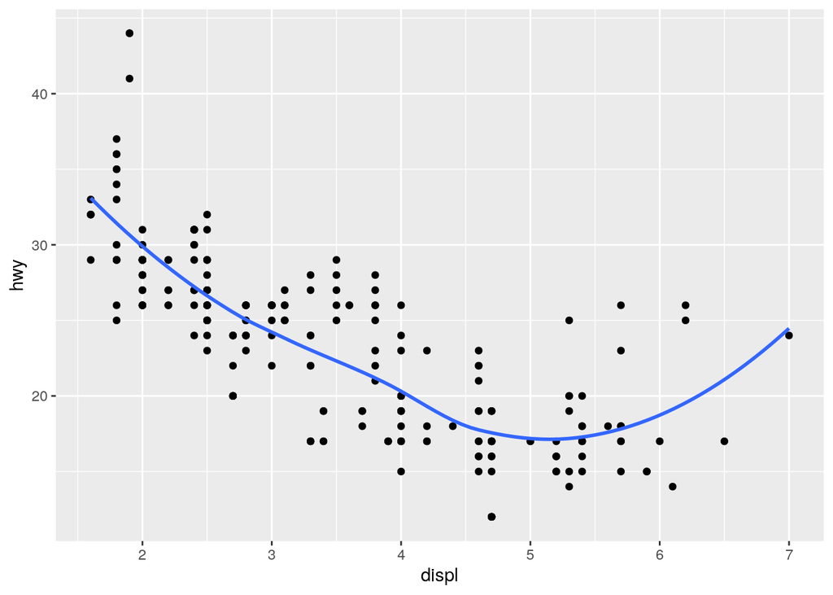

```r
ggplot(mpg, aes(x=displ, y=hwy)) +
  geom_point() +
  geom_smooth(se=FALSE)
```

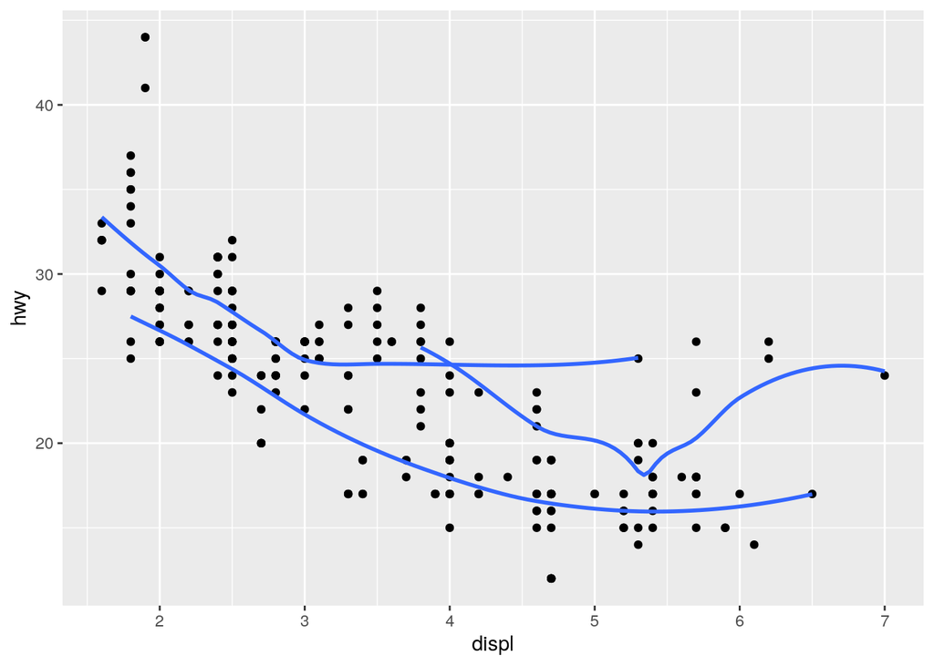

```r
ggplot(mpg, aes(x=displ, y=hwy)) +
  geom_point() +
  geom_smooth(aes(group = drv), se=FALSE)
```

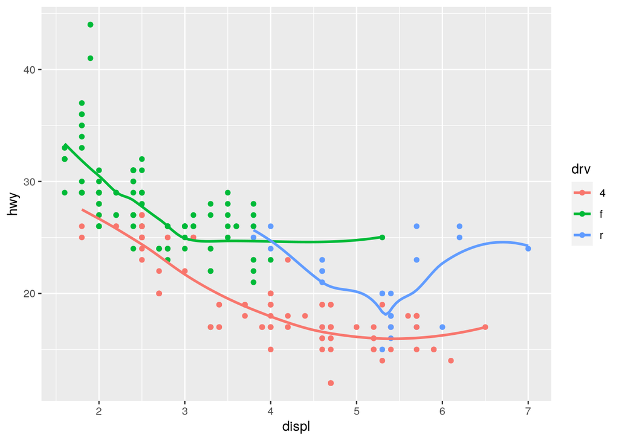

```r
ggplot(mpg, aes(x=displ, y=hwy)) +
  geom_point(aes(color=drv)) +
  geom_smooth(aes(color=drv), se=FALSE)
```

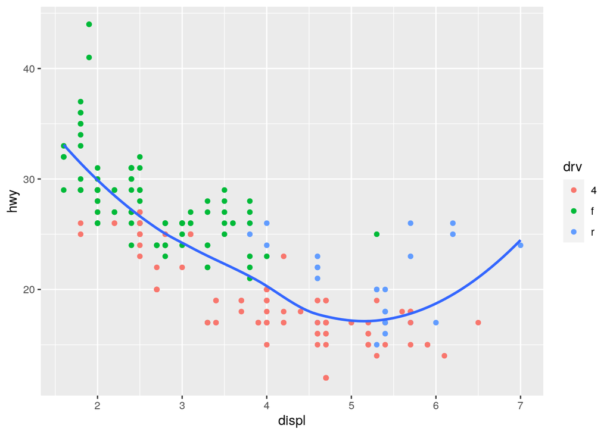

```r
ggplot(mpg, aes(x=displ, y=hwy)) +
  geom_point(aes(color=drv)) +
  geom_smooth(se=FALSE)
```

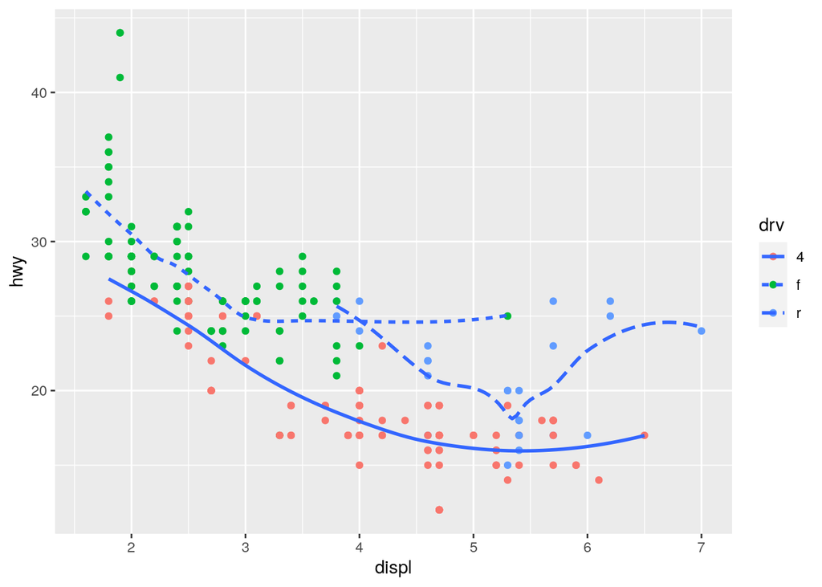

```r
ggplot(mpg, aes(x=displ, y=hwy)) +
  geom_point(aes(color=drv)) +
  geom_smooth(aes(group=drv, linetype=drv), se=FALSE)
```

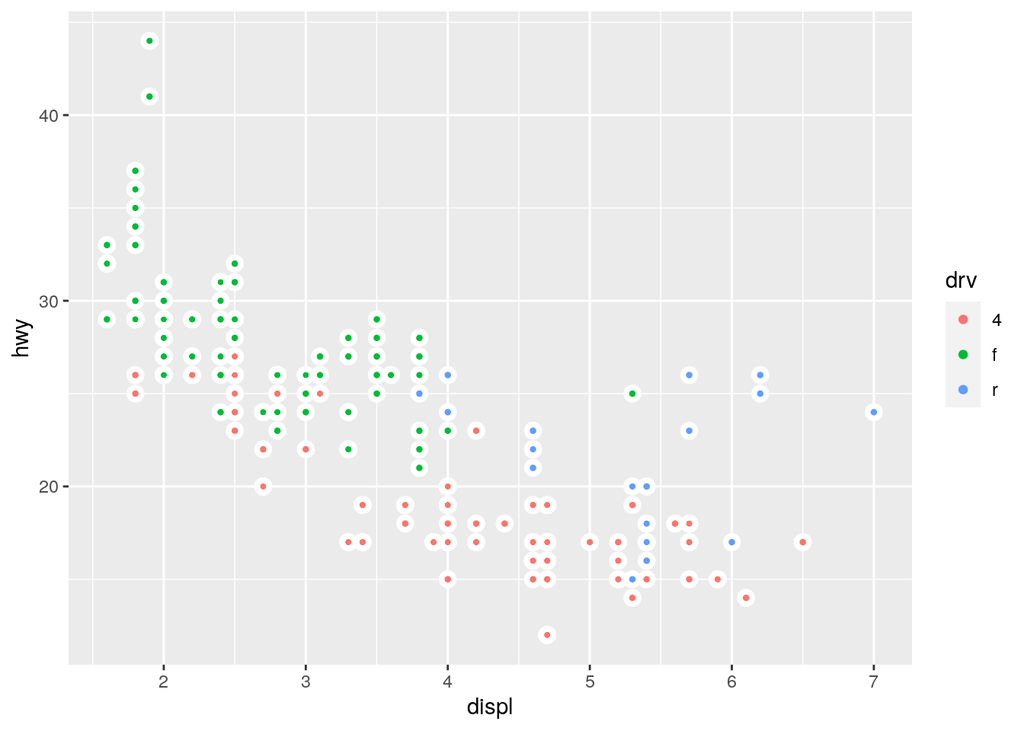

```r
ggplot(mpg, aes(x=displ, y=hwy)) +
  geom_point(aes(color=drv)) +
  geom_point(shape = 21, stroke = 2, color='white')
```

# 3.7 Exercises

These exercises are optional, and no solutions are provided.

# 3.8 Exercises

Complete exercises 1, 2, and 4 only.

## 1

What is the problem with this plot? How could you improve it?

`ggplot(data = mpg, mapping = aes(x = cty, y = hwy)) + geom_point()`

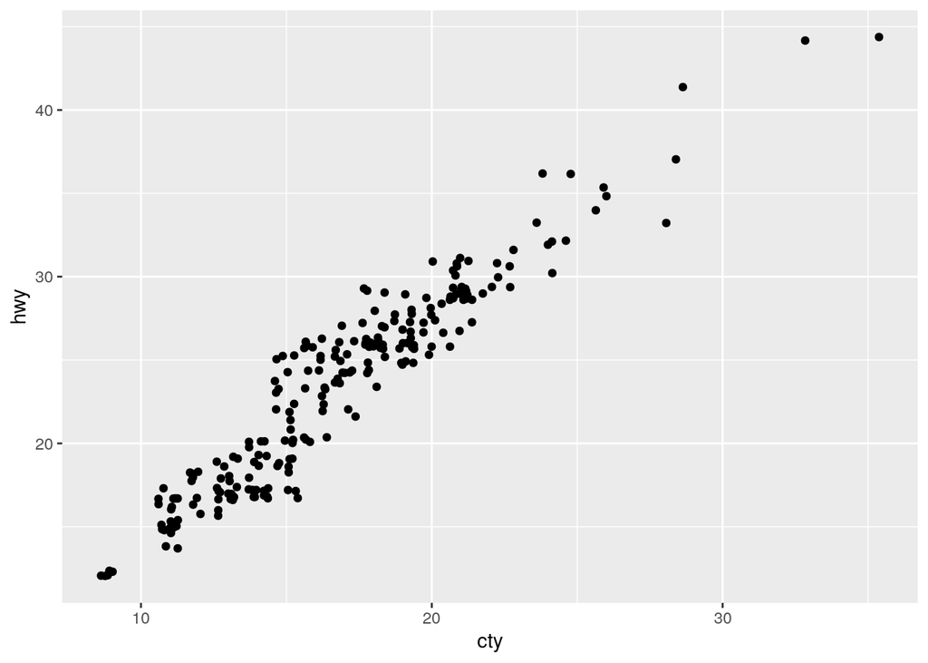

```r
# Add jitter.
ggplot(data = mpg, mapping = aes(x = cty, y = hwy)) +
  geom_point(position = "jitter")
```

```r
# alternatively:
#ggplot(data = mpg, mapping = aes(x = cty, y = hwy)) +
#  geom_jitter()
```

## 2

What parameters to geom_jitter() control the amount of jittering?

```r
# width =
# height =
```

## 4

What’s the default position adjustment for `geom_boxplot()`? Create a visualisation of the `mpg` dataset that demonstrates it.

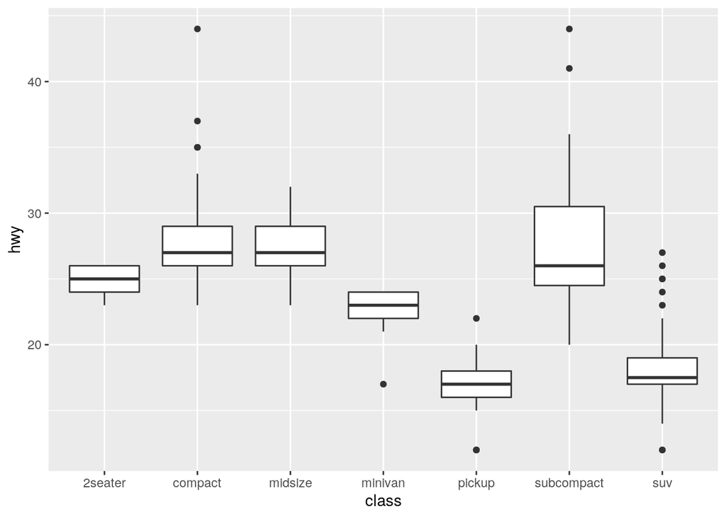

```r
# Default position adjustment is dodge.
# Otherwise we would have superimposed boxplots.

ggplot(mpg, aes(x=class, y=hwy)) +
  geom_boxplot()
```

# 5.1

There are no exercises for this section.

# 5.2 Exercises

Complete exercises 1-3.

## 1 Find all flights that:

1. Had an arrival delay of two or more hours.

```r
flights = nycflights13::flights

flights %>% filter(arr_delay >= 120)
```

```
## # A tibble: 10,200 x 19
##     year month   day dep_time sched_dep_time dep_delay arr_time
##    <int> <int> <int>    <int>          <int>     <dbl>    <int>
##  1  2013     1     1      811            630       101     1047
##  2  2013     1     1      848           1835       853     1001
##  3  2013     1     1      957            733       144     1056
##  4  2013     1     1     1114            900       134     1447
##  5  2013     1     1     1505           1310       115     1638
##  6  2013     1     1     1525           1340       105     1831
##  7  2013     1     1     1549           1445        64     1912
##  8  2013     1     1     1558           1359       119     1718
##  9  2013     1     1     1732           1630        62     2028
## 10  2013     1     1     1803           1620       103     2008
## # … with 10,190 more rows, and 12 more variables: sched_arr_time <int>,
## #   arr_delay <dbl>, carrier <chr>, flight <int>, tailnum <chr>,
## #   origin <chr>, dest <chr>, air_time <dbl>, distance <dbl>, hour <dbl>,
## #   minute <dbl>, time_hour <dttm>
```

2. Flew to Houston (IAH or HOU).

```r
flights %>% filter(dest %in% c('IAH', 'HOU'))
```

```
## # A tibble: 9,313 x 19
##     year month   day dep_time sched_dep_time dep_delay arr_time
##    <int> <int> <int>    <int>          <int>     <dbl>    <int>
##  1  2013     1     1      517            515         2      830
##  2  2013     1     1      533            529         4      850
##  3  2013     1     1      623            627        -4      933
##  4  2013     1     1      728            732        -4     1041
##  5  2013     1     1      739            739         0     1104
##  6  2013     1     1      908            908         0     1228
##  7  2013     1     1     1028           1026         2     1350
##  8  2013     1     1     1044           1045        -1     1352
##  9  2013     1     1     1114            900       134     1447
## 10  2013     1     1     1205           1200         5     1503
## # … with 9,303 more rows, and 12 more variables: sched_arr_time <int>,
## #   arr_delay <dbl>, carrier <chr>, flight <int>, tailnum <chr>,
## #   origin <chr>, dest <chr>, air_time <dbl>, distance <dbl>, hour <dbl>,
## #   minute <dbl>, time_hour <dttm>
```

3. Were operated by United, American, or Delta.

```r
flights %>% filter(carrier %in% c('UA', 'AA', 'DL'))
```

```
## # A tibble: 139,504 x 19
##     year month   day dep_time sched_dep_time dep_delay arr_time
##    <int> <int> <int>    <int>          <int>     <dbl>    <int>
##  1  2013     1     1      517            515         2      830
##  2  2013     1     1      533            529         4      850
##  3  2013     1     1      542            540         2      923
##  4  2013     1     1      554            600        -6      812
##  5  2013     1     1      554            558        -4      740
##  6  2013     1     1      558            600        -2      753
##  7  2013     1     1      558            600        -2      924
##  8  2013     1     1      558            600        -2      923
##  9  2013     1     1      559            600        -1      941
## 10  2013     1     1      559            600        -1      854
## # … with 139,494 more rows, and 12 more variables: sched_arr_time <int>,
## #   arr_delay <dbl>, carrier <chr>, flight <int>, tailnum <chr>,
## #   origin <chr>, dest <chr>, air_time <dbl>, distance <dbl>, hour <dbl>,
## #   minute <dbl>, time_hour <dttm>
```

4. Departed in summer (July, August, and September).

```r
flights %>% filter(month %in% 7:9)
```

```
## # A tibble: 86,326 x 19
##     year month   day dep_time sched_dep_time dep_delay arr_time
##    <int> <int> <int>    <int>          <int>     <dbl>    <int>
##  1  2013     7     1        1           2029       212      236
##  2  2013     7     1        2           2359         3      344
##  3  2013     7     1       29           2245       104      151
##  4  2013     7     1       43           2130       193      322
##  5  2013     7     1       44           2150       174      300
##  6  2013     7     1       46           2051       235      304
##  7  2013     7     1       48           2001       287      308
##  8  2013     7     1       58           2155       183      335
##  9  2013     7     1      100           2146       194      327
## 10  2013     7     1      100           2245       135      337
## # … with 86,316 more rows, and 12 more variables: sched_arr_time <int>,
## #   arr_delay <dbl>, carrier <chr>, flight <int>, tailnum <chr>,
## #   origin <chr>, dest <chr>, air_time <dbl>, distance <dbl>, hour <dbl>,
## #   minute <dbl>, time_hour <dttm>
```

5. Arrived more than two hours late, but didn’t leave late.

```r
flights %>% filter(arr_delay > 120 & dep_delay <= 0)
```

```
## # A tibble: 29 x 19
##     year month   day dep_time sched_dep_time dep_delay arr_time
##    <int> <int> <int>    <int>          <int>     <dbl>    <int>
##  1  2013     1    27     1419           1420        -1     1754
##  2  2013    10     7     1350           1350         0     1736
##  3  2013    10     7     1357           1359        -2     1858
##  4  2013    10    16      657            700        -3     1258
##  5  2013    11     1      658            700        -2     1329
##  6  2013     3    18     1844           1847        -3       39
##  7  2013     4    17     1635           1640        -5     2049
##  8  2013     4    18      558            600        -2     1149
##  9  2013     4    18      655            700        -5     1213
## 10  2013     5    22     1827           1830        -3     2217
## # … with 19 more rows, and 12 more variables: sched_arr_time <int>,
## #   arr_delay <dbl>, carrier <chr>, flight <int>, tailnum <chr>,
## #   origin <chr>, dest <chr>, air_time <dbl>, distance <dbl>, hour <dbl>,
## #   minute <dbl>, time_hour <dttm>
```

6. Were delayed by at least an hour, but made up over 30 minutes in flight.

```r
flights %>% filter(dep_delay >= 60 & arr_delay < dep_delay - 30)
```

```
## # A tibble: 1,844 x 19
##     year month   day dep_time sched_dep_time dep_delay arr_time
##    <int> <int> <int>    <int>          <int>     <dbl>    <int>
##  1  2013     1     1     2205           1720       285       46
##  2  2013     1     1     2326           2130       116      131
##  3  2013     1     3     1503           1221       162     1803
##  4  2013     1     3     1839           1700        99     2056
##  5  2013     1     3     1850           1745        65     2148
##  6  2013     1     3     1941           1759       102     2246
##  7  2013     1     3     1950           1845        65     2228
##  8  2013     1     3     2015           1915        60     2135
##  9  2013     1     3     2257           2000       177       45
## 10  2013     1     4     1917           1700       137     2135
## # … with 1,834 more rows, and 12 more variables: sched_arr_time <int>,
## #   arr_delay <dbl>, carrier <chr>, flight <int>, tailnum <chr>,
## #   origin <chr>, dest <chr>, air_time <dbl>, distance <dbl>, hour <dbl>,
## #   minute <dbl>, time_hour <dttm>
```

```r
# over 30 minutes means <, not <=
```

7. Departed between midnight and 6am (inclusive).

```r
flights %>% filter(dep_time == 2400 | dep_time <= 600)
```

```
## # A tibble: 9,373 x 19
##     year month   day dep_time sched_dep_time dep_delay arr_time
##    <int> <int> <int>    <int>          <int>     <dbl>    <int>
##  1  2013     1     1      517            515         2      830
##  2  2013     1     1      533            529         4      850
##  3  2013     1     1      542            540         2      923
##  4  2013     1     1      544            545        -1     1004
##  5  2013     1     1      554            600        -6      812
##  6  2013     1     1      554            558        -4      740
##  7  2013     1     1      555            600        -5      913
##  8  2013     1     1      557            600        -3      709
##  9  2013     1     1      557            600        -3      838
## 10  2013     1     1      558            600        -2      753
## # … with 9,363 more rows, and 12 more variables: sched_arr_time <int>,
## #   arr_delay <dbl>, carrier <chr>, flight <int>, tailnum <chr>,
## #   origin <chr>, dest <chr>, air_time <dbl>, distance <dbl>, hour <dbl>,
## #   minute <dbl>, time_hour <dttm>
```

## 2

Another useful dplyr filtering helper is `between()`. What does it do? Can you use it to simplify the code needed to answer the previous challenges?

```r
# 4 done again. Others follow the same format.
flights %>% filter(between(month, 7, 9))
```

```
## # A tibble: 86,326 x 19
##     year month   day dep_time sched_dep_time dep_delay arr_time
##    <int> <int> <int>    <int>          <int>     <dbl>    <int>
##  1  2013     7     1        1           2029       212      236
##  2  2013     7     1        2           2359         3      344
##  3  2013     7     1       29           2245       104      151
##  4  2013     7     1       43           2130       193      322
##  5  2013     7     1       44           2150       174      300
##  6  2013     7     1       46           2051       235      304
##  7  2013     7     1       48           2001       287      308
##  8  2013     7     1       58           2155       183      335
##  9  2013     7     1      100           2146       194      327
## 10  2013     7     1      100           2245       135      337
## # … with 86,316 more rows, and 12 more variables: sched_arr_time <int>,
## #   arr_delay <dbl>, carrier <chr>, flight <int>, tailnum <chr>,
## #   origin <chr>, dest <chr>, air_time <dbl>, distance <dbl>, hour <dbl>,
## #   minute <dbl>, time_hour <dttm>
```

## 3

How many flights have a missing `dep_time`? What other variables are missing? What might these rows represent?

```r
flights %>% filter(is.na(dep_time))
```

```
## # A tibble: 8,255 x 19
##     year month   day dep_time sched_dep_time dep_delay arr_time
##    <int> <int> <int>    <int>          <int>     <dbl>    <int>
##  1  2013     1     1       NA           1630        NA       NA
##  2  2013     1     1       NA           1935        NA       NA
##  3  2013     1     1       NA           1500        NA       NA
##  4  2013     1     1       NA            600        NA       NA
##  5  2013     1     2       NA           1540        NA       NA
##  6  2013     1     2       NA           1620        NA       NA
##  7  2013     1     2       NA           1355        NA       NA
##  8  2013     1     2       NA           1420        NA       NA
##  9  2013     1     2       NA           1321        NA       NA
## 10  2013     1     2       NA           1545        NA       NA
## # … with 8,245 more rows, and 12 more variables: sched_arr_time <int>,
## #   arr_delay <dbl>, carrier <chr>, flight <int>, tailnum <chr>,
## #   origin <chr>, dest <chr>, air_time <dbl>, distance <dbl>, hour <dbl>,
## #   minute <dbl>, time_hour <dttm>
```

```r
# 8,255 flights with missing dep_time.
# Other missing variables: arrival and departure info.
# Probably are canceled flights.
```

# 5.3 Exercises

Complete all exercises.

## 1

How could you use `arrange()` to sort all missing values to the start? (Hint: use `is.na()`).

```r
flights %>% arrange(desc(is.na(dep_time)))
```

```
## # A tibble: 336,776 x 19
##     year month   day dep_time sched_dep_time dep_delay arr_time
##    <int> <int> <int>    <int>          <int>     <dbl>    <int>
##  1  2013     1     1       NA           1630        NA       NA
##  2  2013     1     1       NA           1935        NA       NA
##  3  2013     1     1       NA           1500        NA       NA
##  4  2013     1     1       NA            600        NA       NA
##  5  2013     1     2       NA           1540        NA       NA
##  6  2013     1     2       NA           1620        NA       NA
##  7  2013     1     2       NA           1355        NA       NA
##  8  2013     1     2       NA           1420        NA       NA
##  9  2013     1     2       NA           1321        NA       NA
## 10  2013     1     2       NA           1545        NA       NA
## # … with 336,766 more rows, and 12 more variables: sched_arr_time <int>,
## #   arr_delay <dbl>, carrier <chr>, flight <int>, tailnum <chr>,
## #   origin <chr>, dest <chr>, air_time <dbl>, distance <dbl>, hour <dbl>,
## #   minute <dbl>, time_hour <dttm>
```

## 2

Sort flights to find the most delayed flights. Find the flights that left earliest.

```r
# most delayed
flights %>% arrange(desc(dep_delay))
```

```
## # A tibble: 336,776 x 19
##     year month   day dep_time sched_dep_time dep_delay arr_time
##    <int> <int> <int>    <int>          <int>     <dbl>    <int>
##  1  2013     1     9      641            900      1301     1242
##  2  2013     6    15     1432           1935      1137     1607
##  3  2013     1    10     1121           1635      1126     1239
##  4  2013     9    20     1139           1845      1014     1457
##  5  2013     7    22      845           1600      1005     1044
##  6  2013     4    10     1100           1900       960     1342
##  7  2013     3    17     2321            810       911      135
##  8  2013     6    27      959           1900       899     1236
##  9  2013     7    22     2257            759       898      121
## 10  2013    12     5      756           1700       896     1058
## # … with 336,766 more rows, and 12 more variables: sched_arr_time <int>,
## #   arr_delay <dbl>, carrier <chr>, flight <int>, tailnum <chr>,
## #   origin <chr>, dest <chr>, air_time <dbl>, distance <dbl>, hour <dbl>,
## #   minute <dbl>, time_hour <dttm>
```

```r
# left earliest
flights %>% arrange(dep_delay)
```

```
## # A tibble: 336,776 x 19
##     year month   day dep_time sched_dep_time dep_delay arr_time
##    <int> <int> <int>    <int>          <int>     <dbl>    <int>
##  1  2013    12     7     2040           2123       -43       40
##  2  2013     2     3     2022           2055       -33     2240
##  3  2013    11    10     1408           1440       -32     1549
##  4  2013     1    11     1900           1930       -30     2233
##  5  2013     1    29     1703           1730       -27     1947
##  6  2013     8     9      729            755       -26     1002
##  7  2013    10    23     1907           1932       -25     2143
##  8  2013     3    30     2030           2055       -25     2213
##  9  2013     3     2     1431           1455       -24     1601
## 10  2013     5     5      934            958       -24     1225
## # … with 336,766 more rows, and 12 more variables: sched_arr_time <int>,
## #   arr_delay <dbl>, carrier <chr>, flight <int>, tailnum <chr>,
## #   origin <chr>, dest <chr>, air_time <dbl>, distance <dbl>, hour <dbl>,
## #   minute <dbl>, time_hour <dttm>
```

## 3

Sort flights to find the fastest (highest speed) flights.

```r
flights %>% arrange(desc(distance/air_time*60))
```

```
## # A tibble: 336,776 x 19
##     year month   day dep_time sched_dep_time dep_delay arr_time
##    <int> <int> <int>    <int>          <int>     <dbl>    <int>
##  1  2013     5    25     1709           1700         9     1923
##  2  2013     7     2     1558           1513        45     1745
##  3  2013     5    13     2040           2025        15     2225
##  4  2013     3    23     1914           1910         4     2045
##  5  2013     1    12     1559           1600        -1     1849
##  6  2013    11    17      650            655        -5     1059
##  7  2013     2    21     2355           2358        -3      412
##  8  2013    11    17      759            800        -1     1212
##  9  2013    11    16     2003           1925        38       17
## 10  2013    11    16     2349           2359       -10      402
## # … with 336,766 more rows, and 12 more variables: sched_arr_time <int>,
## #   arr_delay <dbl>, carrier <chr>, flight <int>, tailnum <chr>,
## #   origin <chr>, dest <chr>, air_time <dbl>, distance <dbl>, hour <dbl>,
## #   minute <dbl>, time_hour <dttm>
```

## 4

Which flights travelled the farthest? Which travelled the shortest?

```r
# the farthest
flights %>% arrange(desc(distance))
```

```
## # A tibble: 336,776 x 19
##     year month   day dep_time sched_dep_time dep_delay arr_time
##    <int> <int> <int>    <int>          <int>     <dbl>    <int>
##  1  2013     1     1      857            900        -3     1516
##  2  2013     1     2      909            900         9     1525
##  3  2013     1     3      914            900        14     1504
##  4  2013     1     4      900            900         0     1516
##  5  2013     1     5      858            900        -2     1519
##  6  2013     1     6     1019            900        79     1558
##  7  2013     1     7     1042            900       102     1620
##  8  2013     1     8      901            900         1     1504
##  9  2013     1     9      641            900      1301     1242
## 10  2013     1    10      859            900        -1     1449
## # … with 336,766 more rows, and 12 more variables: sched_arr_time <int>,
## #   arr_delay <dbl>, carrier <chr>, flight <int>, tailnum <chr>,
## #   origin <chr>, dest <chr>, air_time <dbl>, distance <dbl>, hour <dbl>,
## #   minute <dbl>, time_hour <dttm>
```

```r
# the shortest
flights %>% arrange(distance)
```

```
## # A tibble: 336,776 x 19
##     year month   day dep_time sched_dep_time dep_delay arr_time
##    <int> <int> <int>    <int>          <int>     <dbl>    <int>
##  1  2013     7    27       NA            106        NA       NA
##  2  2013     1     3     2127           2129        -2     2222
##  3  2013     1     4     1240           1200        40     1333
##  4  2013     1     4     1829           1615       134     1937
##  5  2013     1     4     2128           2129        -1     2218
##  6  2013     1     5     1155           1200        -5     1241
##  7  2013     1     6     2125           2129        -4     2224
##  8  2013     1     7     2124           2129        -5     2212
##  9  2013     1     8     2127           2130        -3     2304
## 10  2013     1     9     2126           2129        -3     2217
## # … with 336,766 more rows, and 12 more variables: sched_arr_time <int>,
## #   arr_delay <dbl>, carrier <chr>, flight <int>, tailnum <chr>,
## #   origin <chr>, dest <chr>, air_time <dbl>, distance <dbl>, hour <dbl>,
## #   minute <dbl>, time_hour <dttm>
```

# 5.4 Exercises

Complete exercises 2-4.

## 2

What happens if you include the name of a variable multiple times in a `select()` call?

```r
flights %>% select(carrier, carrier)
```

```
## # A tibble: 336,776 x 1
##    carrier
##    <chr>
##  1 UA
##  2 UA
##  3 AA
##  4 B6
##  5 DL
##  6 UA
##  7 B6
##  8 EV
##  9 B6
## 10 AA
## # … with 336,766 more rows
```

```r
# It only includes the column once.
```

## 3

What does the `one_of()` function do? Why might it be helpful in conjunction with this vector?

`vars <- c("year", "month", "day", "dep_delay", "arr_delay")`

Note: the `tidyselect` documentation states:

> `one_of()` is retired in favour of the more precise `any_of()` and `all_of()` selectors.

```r
vars <- c("year", "month", "day", "dep_delay", "arr_delay")

flights %>% select(one_of(vars))
```

```
## # A tibble: 336,776 x 5
##     year month   day dep_delay arr_delay
##    <int> <int> <int>     <dbl>     <dbl>
##  1  2013     1     1         2        11
##  2  2013     1     1         4        20
##  3  2013     1     1         2        33
##  4  2013     1     1        -1       -18
##  5  2013     1     1        -6       -25
##  6  2013     1     1        -4        12
##  7  2013     1     1        -5        19
##  8  2013     1     1        -3       -14
##  9  2013     1     1        -3        -8
## 10  2013     1     1        -2         8
## # … with 336,766 more rows
```

## 4

Does the result of running the following code surprise you? How do the select helpers deal with case by default? How can you change that default?

`select(flights, contains("TIME"))`

```r
select(flights, contains("TIME"))
```

```
## # A tibble: 336,776 x 6
##    dep_time sched_dep_time arr_time sched_arr_time air_time
##       <int>          <int>    <int>          <int>    <dbl>
##  1      517            515      830            819      227
##  2      533            529      850            830      227
##  3      542            540      923            850      160
##  4      544            545     1004           1022      183
##  5      554            600      812            837      116
##  6      554            558      740            728      150
##  7      555            600      913            854      158
##  8      557            600      709            723       53
##  9      557            600      838            846      140
## 10      558            600      753            745      138
## # … with 336,766 more rows, and 1 more variable: time_hour <dttm>
```

```r
select(flights, contains("TIME", ignore.case=FALSE))
```

```
## # A tibble: 336,776 x 0
```

```r
# select helpers ignore case
```

# 5.5 Exercises

Complete exercises 1-3.

## 1

Currently `dep_time` and `sched_dep_time` are convenient to look at, but hard to compute with because they’re not really continuous numbers. Convert them to a more convenient representation of number of minutes since midnight.

```r
flights %>% mutate(dep_since_midnight = (dep_time %/% 100) * 60 + dep_time %% 100,
                   sched_dep_since_midnight = (sched_dep_time %/% 100) * 60 + sched_dep_time %% 100
                   ) %>%
  select(dep_time, sched_dep_time, dep_since_midnight, sched_dep_since_midnight)
```

```
## # A tibble: 336,776 x 4
##    dep_time sched_dep_time dep_since_midnight sched_dep_since_midnight
##       <int>          <int>              <dbl>                    <dbl>
##  1      517            515                317                      315
##  2      533            529                333                      329
##  3      542            540                342                      340
##  4      544            545                344                      345
##  5      554            600                354                      360
##  6      554            558                354                      358
##  7      555            600                355                      360
##  8      557            600                357                      360
##  9      557            600                357                      360
## 10      558            600                358                      360
## # … with 336,766 more rows
```

## 2

Compare `air_time` with `arr_time - dep_time`. What do you expect to see? What do you see? What do you need to do to fix it?

```r
flights %>%
  mutate(diff = ((arr_time %/% 100) * 60 + arr_time %% 100) -
           ((dep_time %/% 100) * 60 + dep_time %% 100)) %>%
  select(arr_time, dep_time, diff)
```

```
## # A tibble: 336,776 x 3
##    arr_time dep_time  diff
##       <int>    <int> <dbl>
##  1      830      517   193
##  2      850      533   197
##  3      923      542   221
##  4     1004      544   260
##  5      812      554   138
##  6      740      554   106
##  7      913      555   198
##  8      709      557    72
##  9      838      557   161
## 10      753      558   115
## # … with 336,766 more rows
```

```r
# Need to account for changing time zones and taxi-ing times.
```

## 3

Compare `dep_time`, `sched_dep_time`, and `dep_delay`. How would you expect those three numbers to be related?

```r
flights %>%
  mutate(diff = ((dep_time %/% 100) * 60 + dep_time %% 100) -
           ((sched_dep_time %/% 100) * 60 + sched_dep_time %% 100)) %>%
  select(diff, dep_delay)
```

```
## # A tibble: 336,776 x 2
##     diff dep_delay
##    <dbl>     <dbl>
##  1     2         2
##  2     4         4
##  3     2         2
##  4    -1        -1
##  5    -6        -6
##  6    -4        -4
##  7    -5        -5
##  8    -3        -3
##  9    -3        -3
## 10    -2        -2
## # … with 336,766 more rows
```

# 5.6 Exercises

Complete exercises 1, 2, and 4.

## 1

For this exercise, just find one way of solving the problem.

A flight is 15 minutes early 50% of the time, and 15 minutes late 50% of the time.

```r
not_cancelled = flights %>% filter(!is.na(dep_delay), !is.na(arr_delay))

not_cancelled %>%
  group_by(flight) %>%
  summarize(prop_early = mean(arr_delay <= -15),
            prop_late = mean(arr_delay >= 15)) %>%
  filter(prop_early == 0.5 & prop_late == 0.5)
```

```
## # A tibble: 21 x 3
##    flight prop_early prop_late
##     <int>      <dbl>     <dbl>
##  1    107        0.5       0.5
##  2   2072        0.5       0.5
##  3   2366        0.5       0.5
##  4   2500        0.5       0.5
##  5   2552        0.5       0.5
##  6   3495        0.5       0.5
##  7   3505        0.5       0.5
##  8   3518        0.5       0.5
##  9   3544        0.5       0.5
## 10   3651        0.5       0.5
## # … with 11 more rows
```

A flight is always 10 minutes late.

```r
not_cancelled %>%
  group_by(flight) %>%
  summarize(prop_late = mean(arr_delay >= 10)) %>%
  filter(prop_late == 1.0)
```

```
## # A tibble: 98 x 2
##    flight prop_late
##     <int>     <dbl>
##  1     94         1
##  2    730         1
##  3    974         1
##  4   1084         1
##  5   1226         1
##  6   1510         1
##  7   1514         1
##  8   1859         1
##  9   1868         1
## 10   1998         1
## # … with 88 more rows
```

A flight is 30 minutes early 50% of the time, and 30 minutes late 50% of the time.

```r
not_cancelled %>%
  group_by(flight) %>%
  summarize(prop_early = mean(arr_delay <= -30),
            prop_late = mean(arr_delay >= 30)) %>%
  filter(prop_early == 0.5 & prop_late == 0.5)
```

```
## # A tibble: 3 x 3
##   flight prop_early prop_late
##    <int>      <dbl>     <dbl>
## 1   3651        0.5       0.5
## 2   3916        0.5       0.5
## 3   3951        0.5       0.5
```

99% of the time a flight is on time. 1% of the time it’s 2 hours late.

```r
not_cancelled %>%
  group_by(flight) %>%
  summarize(prop_ontime = mean(dep_delay <= 0),
            prop_late = mean(dep_delay >= 120)) %>%
  filter(prop_ontime >= 0.99 & prop_late <= 0.01)
```

```
## # A tibble: 361 x 3
##    flight prop_ontime prop_late
##     <int>       <dbl>     <dbl>
##  1     46           1         0
##  2     88           1         0
##  3     90           1         0
##  4     99           1         0
##  5    100           1         0
##  6    122           1         0
##  7    513           1         0
##  8    648           1         0
##  9    748           1         0
## 10    760           1         0
## # … with 351 more rows
```

## 2

Come up with another approach that will give you the same output as `not_cancelled %>% count(dest)` and `not_cancelled %>% count(tailnum, wt = distance)` without using `count()`.

```r
# not_cancelled %>% count(dest)
not_cancelled %>%
  group_by(dest) %>%
  summarize(dest_sum = n())
```

```
## # A tibble: 104 x 2
##    dest  dest_sum
##    <chr>    <int>
##  1 ABQ        254
##  2 ACK        264
##  3 ALB        418
##  4 ANC          8
##  5 ATL      16837
##  6 AUS       2411
##  7 AVL        261
##  8 BDL        412
##  9 BGR        358
## 10 BHM        269
## # … with 94 more rows
```

```r
# not_cancelled %>% count(tailnum, wt = distance)
not_cancelled %>%
  group_by(tailnum) %>%
  summarize(sum_dist = sum(distance))
```

```
## # A tibble: 4,037 x 2
##    tailnum sum_dist
##    <chr>      <dbl>
##  1 D942DN      3418
##  2 N0EGMQ    239143
##  3 N10156    109664
##  4 N102UW     25722
##  5 N103US     24619
##  6 N104UW     24616
##  7 N10575    139903
##  8 N105UW     23618
##  9 N107US     21677
## 10 N108UW     32070
## # … with 4,027 more rows
```

## 4

Look at the number of cancelled flights per day. Is there a pattern? Is the proportion of cancelled flights related to the average delay?

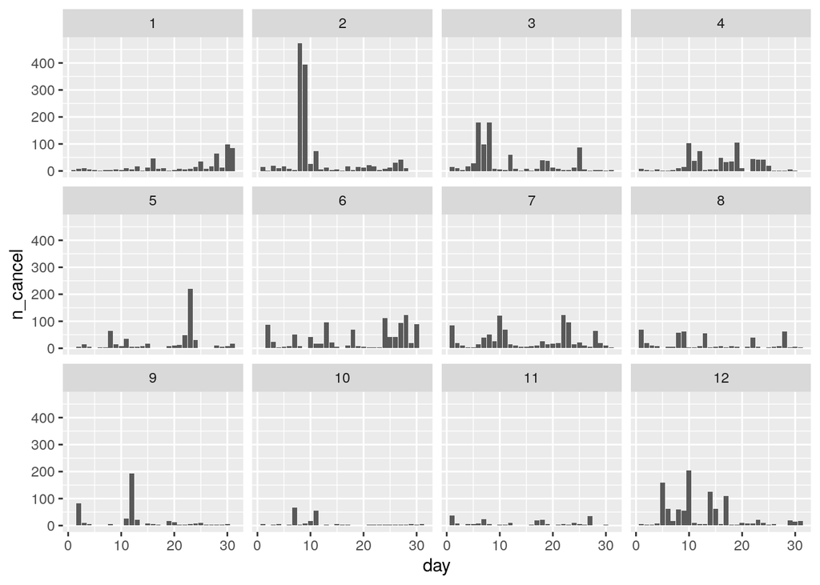

```r
# number of cancelled flights per day faceted by month
flights %>%
  group_by(year, month, day) %>%
  summarize(n_cancel = sum(is.na(dep_delay))) %>%
  ggplot() +
  geom_col(aes(x=day, y=n_cancel)) +
  facet_wrap(~month)
```

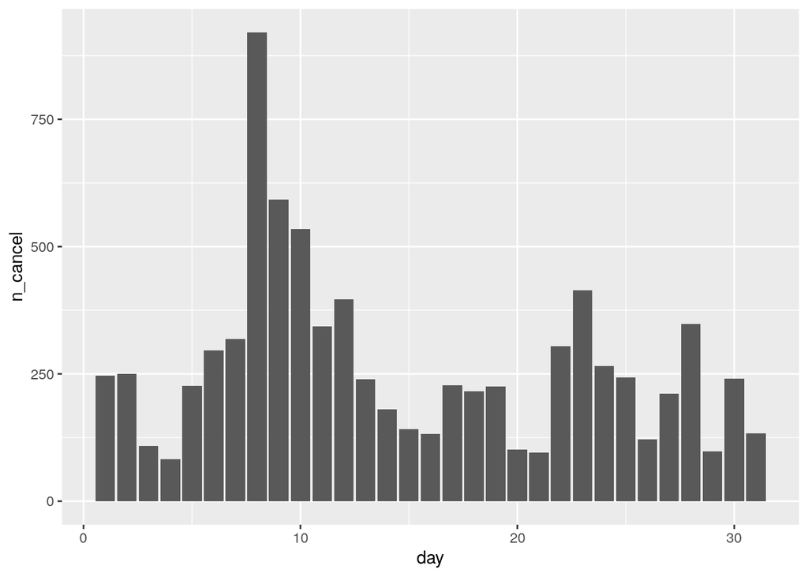

```r
# days combined from each month
flights %>%
  group_by(day) %>%
  summarize(n_cancel = sum(is.na(dep_delay))) %>%
  ggplot() +
  geom_col(aes(x=day, y=n_cancel))
```

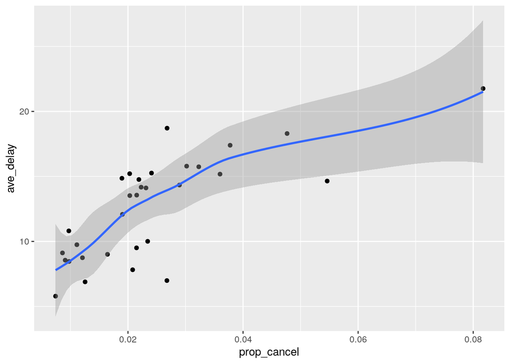

```r
flights %>%
  group_by(day) %>%
  summarize(prop_cancel = mean(is.na(dep_delay)),
            ave_delay = mean(dep_delay[!is.na(dep_delay)])) %>%
  ggplot() +
  geom_point(aes(x=prop_cancel, y=ave_delay)) +
  geom_smooth(aes(x=prop_cancel, y=ave_delay))
```

# 5.7 Exercises

Complete exercises 2 and 3.

## 2

Which plane (`tailnum`) has the worst on-time record?

```r
# If we define "worst on-time record" as the percent of flights a tailnum arrives late:

not_cancelled %>%
  group_by(tailnum) %>%
  summarize(pct_late = mean(arr_delay>0)) %>%
  arrange(desc(pct_late))
```

```
## # A tibble: 4,037 x 2
##    tailnum pct_late
##    <chr>      <dbl>
##  1 N121DE         1
##  2 N136DL         1
##  3 N143DA         1
##  4 N17627         1
##  5 N240AT         1
##  6 N26906         1
##  7 N295AT         1
##  8 N302AS         1
##  9 N303AS         1
## 10 N32626         1
## # … with 4,027 more rows
```

## 3

What time of day should you fly if you want to avoid delays as much as possible?

```r
# Looking at it from the perspective of departure delay:

not_cancelled %>%
  mutate(time_of_day = case_when(
    sched_dep_time < 0600 ~ "early_morning",
    between(sched_dep_time, 0600, 1200) ~ "morning",
    between(sched_dep_time, 1200, 1800) ~ "afternoon",
    sched_dep_time > 1800 ~ "night")) %>%
  group_by(time_of_day) %>%
  summarize(pct_late = mean(dep_delay>0)) %>%
  arrange(pct_late)
```

```
## # A tibble: 4 x 2
##   time_of_day   pct_late
##   <chr>            <dbl>
## 1 early_morning    0.251
## 2 morning          0.257
## 3 afternoon        0.462
## 4 night            0.519
```

```r
# Alternatively, we could define "avoid delays" as arriving on time.
```